# COMPARE HSP2 TO HSPF USING CALLEG

[figure not shown]

Copyright 2020 for this Jupyter Notebook and YouTube Video by RESPEC, INC. All rights reserved.

$\textbf{HSP}^{\textbf{2}}\ \text{and}\ \textbf{HSP2}\ $ Copyright 2020 by RESPEC INC. and released under the *GNU AFFERO GENERAL PUBLIC LICENSE*

This Notebook will compare the results of running HSPF and HSP$^2$ for the basic hydrology (PWATER, IWATER, and HYDR) to confirm the proper calculations of HSP$^2$

Calleg is a real watershed and has

- 27 IMPLND segments,
- 129 PERLND segments,
- 119 RCHRES segments,
- 9 years of simulation time with hourly time steps (78,888 timesteps) from 1993-10-01 to 2002-10-01

This Notebook assumes HSPF has been run and the HBN data saved to an HDF5 file in the **HSPF RUN** directory.

import os os.environ['NUMBA_DISABLE_JIT'] = '1' # '1' turns off Numba for this session only

## Required Python imports and setup

```python
from pandas import options, read_hdf, DataFrame
from matplotlib import pyplot as plt

# Set display options for convenience, does't change the data
options.display.max_rows    = 25
options.display.max_columns = 20
options.display.float_format = '{:.4f}'.format  # display 4 digits after the decimal point

%matplotlib inline

from HSP2 import main, versions
from HSP2tools import readWDM, readUCI
versions(['matplotlib'])
```

|  | version |
| --- | --- |
| Python | 3.8.2 \| packaged by conda-forge \| (default, Ap... |
| HSP2 | 1.0.0 |
| numpy | 1.18.1 |
| numba | 0.48.0 |
| pandas | 1.0.3 |
| matplotlib | 3.2.1 |
| os | Windows-10-10.0.18362-SP0 |
| processor | Intel64 Family 6 Model 94 Stepping 3, GenuineI... |
| Date/Time | 2020-04-29 16:05:48 |

Convenient name strings to get to the data

```python
wdmname = 'HSPF run/calleg.wdm'
uciname = 'HSPF run/calleg.uci'
HBN     = 'HSPF run/HBN.h5'
hdfname = 'calleg.h5'
```

## Run HSP2 on the calleg

### Create HDF5 file

```python
readUCI(uciname, hdfname)
readWDM(wdmname, hdfname)
```

|  | Start | Stop | Freq | Length | TSTYPE | TFILL | STNAM | SCENARIO | CONSTITUENT | LOCATION |
| --- | --- | --- | --- | --- | --- | --- | --- | --- | --- | --- |
| TS401 | 1987-01-01 00:00:00 | 2004-01-01 00:00:00 | 1MS | 204 | PUMP | -999.0000 | Cumulative Flow of 6 Downtown GW Wells | OBSERVED | PUMPOUT | DOWNTOWN |
| TS402 | 1987-01-01 00:00:00 | 2004-01-01 00:00:00 | 1MS | 204 | PUMP | -999.0000 | Flow of GW pumped into storm drain by Pump #31 i | OBSERVED | PUMPOUT | PUMP_#31 |
| TS403 | 1987-01-01 00:00:00 | 2004-01-01 00:00:00 | 1MS | 204 | PUMP | -999.0000 | Flow of GW pumped into storm drain @ 2020 First | OBSERVED | PUMPIN | 2020_1ST |
| TS404 | 1987-01-01 00:00:00 | 2004-01-01 00:00:00 | 1MS | 204 | PUMP | -999.0000 | Flow of GW pumped into storm drain @ Chain Dr in | OBSERVED | PUMPIN | CHAIN_DR |
| TS405 | 1987-01-01 00:00:00 | 2004-01-01 00:00:00 | 1MS | 204 | PUMP | -999.0000 | Flow of GW pumped into storm drain @ Madera in S | OBSERVED | PUMPIN | MADERA |
| ... | ... | ... | ... | ... | ... | ... | ... | ... | ... | ... |
| TS9204 | 1987-01-01 00:00:00 | 2003-01-01 00:00:00 | 1D | 5844 | AGWO | -999.0000 |  | CALLEG | AGWO | MADERA |
| TS9911 | 1987-01-01 00:00:00 | 2003-01-01 00:00:00 | 1D | 5844 | FLOW | -999.0000 |  | CALLEG | FLOW | ARROY838 |
| TS9403 | 1987-01-01 00:00:00 | 2003-01-01 00:00:00 | 1D | 5844 | IFWO | -999.0000 |  | CALLEG | IFWO | REVOLON |
| TS9409 | 1987-01-01 00:00:00 | 2003-01-01 00:00:00 | 1H | 140256 | WPPT | -999.0000 |  | CALLEG | WPPT | REVOLON |
| TS9802 | 1987-01-01 00:00:00 | 2003-01-01 00:00:00 | 1D | 5844 | SURO | -999.0000 |  | CALLEG | SURO | BEARDSLY |

235 rows × 10 columns

### Run

```python
main(hdfname, saveall=True)
```

```
2020-04-29 16:06:19.92   Processing started for file calleg.h5; saveall=True
2020-04-29 16:06:21.73   Simulation Start: 1993-10-01 00:00:00, Stop: 2002-10-01 00:00:00
2020-04-29 16:06:21.73      PERLND P011 DELT(minutes): 60
2020-04-29 16:06:23.67         PWATER
2020-04-29 16:06:24.95      PERLND P012 DELT(minutes): 60
2020-04-29 16:06:25.03         PWATER
2020-04-29 16:06:25.19      PERLND P013 DELT(minutes): 60
2020-04-29 16:06:25.28         PWATER
2020-04-29 16:06:25.44      PERLND P014 DELT(minutes): 60
2020-04-29 16:06:25.53         PWATER
2020-04-29 16:06:25.70      PERLND P015 DELT(minutes): 60
2020-04-29 16:06:25.79         PWATER
2020-04-29 16:06:25.95      IMPLND I011 DELT(minutes): 60
2020-04-29 16:06:26.01         IWATER
2020-04-29 16:06:26.10      PERLND P021 DELT(minutes): 60
2020-04-29 16:06:26.15         PWATER
2020-04-29 16:06:26.32      PERLND P022 DELT(minutes): 60
2020-04-29 16:06:26.41         PWATER
2020-04-29 16:06:26.57      PERLND P023 DELT(minutes): 60
2020-04-29 16:06:26.66         PWATER
2020-04-29 16:06:26.82      PERLND P024 DELT(minutes): 60
2020-04-29 16:06:26.91         PWATER
2020-04-29 16:06:27.07      PERLND P025 DELT(minutes): 60
2020-04-29 16:06:27.16         PWATER
2020-04-29 16:06:27.32      IMPLND I021 DELT(minutes): 60
2020-04-29 16:06:27.38         IWATER
2020-04-29 16:06:27.46      RCHRES R001 DELT(minutes): 60
2020-04-29 16:06:27.51         HYDR
2020-04-29 16:06:28.22      PERLND P031 DELT(minutes): 60
2020-04-29 16:06:28.28         PWATER
2020-04-29 16:06:28.45      PERLND P041 DELT(minutes): 60
2020-04-29 16:06:28.51         PWATER
2020-04-29 16:06:28.67      PERLND P042 DELT(minutes): 60
2020-04-29 16:06:28.76         PWATER
2020-04-29 16:06:28.92      PERLND P043 DELT(minutes): 60
2020-04-29 16:06:29.01         PWATER
2020-04-29 16:06:29.17      IMPLND I041 DELT(minutes): 60
2020-04-29 16:06:29.23         IWATER
2020-04-29 16:06:29.32      RCHRES R021 DELT(minutes): 60
2020-04-29 16:06:29.37         HYDR
```

[output cut: 515 more lines]

```
2020-04-29 16:07:41.30         HYDR
2020-04-29 16:07:41.56   Done; Run time is about 01:21.6 (mm:ss)


                                                       version
Python      3.8.2 | packaged by conda-forge | (default, Ap...
HSP2                                                    1.0.0
numpy                                                  1.18.1
numba                                                  0.48.0
pandas                                                  1.0.3
jupyterlab                                              2.1.1
notebook                                                6.0.3
os                                  Windows-10-10.0.18362-SP0
processor   Intel64 Family 6 Model 94 Stepping 3, GenuineI...
Date/Time                                 2020-04-29 16:07:41
```

Development note: SAVEALL = FALSE (new SAVE table for hot restart by default) 2017-04-16 09:05:26.10 Run completed 1 loop, best of 3: 32.3 s per loop Ratio of HSP2/HSPF 32.3/24.4 = 1.3 SAVEALL = TRUE 2017-04-11 10:18:22.86 Run completed 1 loop, best of 3: 38.1 s per loop Ratio of HSP2/HSPF 38.1/24.4 = 1.6 04/25/2020 New Python 3 version is about 1.8x slower than HSPF - even when all tricks used. However, the new Numba Dict and List implementations are SLOW in the code outside numba - on the order of ms vs us which can easily explain the difference.

## Read Summary from HBN file

Find the higest frequency data available.

```python
summary = read_hdf(HBN, 'SUMMARY')
summary.Frequency.unique()
```

```
array(['Monthly', 'Yearly'], dtype=object)
```

So the best available is monthly data.

## Automate checking by output flow

```python
def hsp2key(hspfkey):
    op, activity, segment, _ = hspfkey.split('_')
    return  f'RESULTS/{op}_{op[0]}{segment:0>3s}/{activity}'
```

```python
def monthlyoutflow(keys, flowname):
    data = DataFrame()
    for key in keys.index:
        hsp2 = read_hdf(hdfname, hsp2key(key))[flowname].resample('M').sum().to_numpy()
        hspf = read_hdf(HBN, key)[flowname].to_numpy()

        hsp2sum = hsp2.sum()
        hspfsum = hspf.sum()

        segment = key.split('_')[2]

        data.loc[segment, 'HSP2 SUM'] = hsp2.sum()
        data.loc[segment, 'HSPF SUM'] = hspf.sum()
        data.loc[segment, 'Percent diff']      = 100.0 *    (hspfsum - hsp2sum)/hspfsum
        data.loc[segment, 'abs(Percent diff)'] = 100.0 * abs(hspfsum - hsp2sum)/hspfsum

    return data.sort_values(by=['abs(Percent diff)'])
```

### Define a function to plot HSPF and HSP2 data

```python
def plot(operation, ils, activity, name, how='sum'):
    hspf = f'{operation}_{activity}_{ils:0>3s}_4'
    tshspf = read_hdf(HBN, hspf)[name]

    hsp2 = f'RESULTS/{operation}_{operation[0]}{ils:0>3s}/{activity}'
    if how == 'sum':
        tshsp2 = read_hdf(hdfname, hsp2)[name].resample('M').sum().shift(1,'D')
    elif how == 'last':
        tshsp2 = read_hdf(hdfname, hsp2)[name].resample('M').last().shift(1,'D')

    plt.figure(figsize=(10,8))
    plt.plot(tshspf.index, tshspf, label='HSPF', color='r')
    plt.plot(tshsp2.index, tshsp2, label='HSP2', color='b')
    plt.legend()
    plt.title(f'{operation} {operation[0]}{ils:0>3s}, {activity} {name}')
```

```python
def scatter(operation, ils, activity, name, how='sum'):
    hspf = f'{operation}_{activity}_{ils:0>3s}_4'
    tshspf = read_hdf(HBN, hspf)[name]

    hsp2 = f'RESULTS/{operation}_{operation[0]}{ils:0>3s}/{activity}'
    if how == 'sum':
        tshsp2 = read_hdf(hdfname, hsp2)[name].resample('M').sum().shift(1,'D')
    elif how == 'last':
        tshsp2 = read_hdf(hdfname, hsp2)[name].resample('M').last().shift(1,'D')

    plt.scatter(tshspf, tshsp2)
```

### IMPLND

```python
implndkeys = summary[(summary.Frequency=='Monthly') & (summary.Operation=='IMPLND')]
implndkeys
```

|  | Operation | Activity | segment | Frequency | Shape | Start | Stop |
| --- | --- | --- | --- | --- | --- | --- | --- |
| IMPLND_IWATER_011_4 | IMPLND | IWATER | 11 | Monthly | (108, 6) | 1993-11-01 | 2002-10-01 |
| IMPLND_IWATER_021_4 | IMPLND | IWATER | 21 | Monthly | (108, 6) | 1993-11-01 | 2002-10-01 |
| IMPLND_IWATER_041_4 | IMPLND | IWATER | 41 | Monthly | (108, 6) | 1993-11-01 | 2002-10-01 |
| IMPLND_IWATER_051_4 | IMPLND | IWATER | 51 | Monthly | (108, 6) | 1993-11-01 | 2002-10-01 |
| IMPLND_IWATER_061_4 | IMPLND | IWATER | 61 | Monthly | (108, 6) | 1993-11-01 | 2002-10-01 |
| ... | ... | ... | ... | ... | ... | ... | ... |
| IMPLND_IWATER_251_4 | IMPLND | IWATER | 251 | Monthly | (108, 6) | 1993-11-01 | 2002-10-01 |
| IMPLND_IWATER_271_4 | IMPLND | IWATER | 271 | Monthly | (108, 6) | 1993-11-01 | 2002-10-01 |
| IMPLND_IWATER_281_4 | IMPLND | IWATER | 281 | Monthly | (108, 6) | 1993-11-01 | 2002-10-01 |
| IMPLND_IWATER_291_4 | IMPLND | IWATER | 291 | Monthly | (108, 6) | 1993-11-01 | 2002-10-01 |
| IMPLND_IWATER_301_4 | IMPLND | IWATER | 301 | Monthly | (108, 6) | 1993-11-01 | 2002-10-01 |

27 rows × 7 columns

```python
delta = monthlyoutflow(implndkeys, 'SURO')
delta
```

|  | HSP2 SUM | HSPF SUM | Percent diff | abs(Percent diff) |
| --- | --- | --- | --- | --- |
| 291 | 117.5699 | 117.5699 | -0.0000 | 0.0000 |
| 281 | 137.7904 | 137.7904 | 0.0000 | 0.0000 |
| 101 | 144.1288 | 144.1288 | -0.0000 | 0.0000 |
| 021 | 122.5966 | 122.5966 | 0.0000 | 0.0000 |
| 051 | 120.2708 | 120.2708 | 0.0000 | 0.0000 |
| ... | ... | ... | ... | ... |
| 301 | 119.8081 | 119.8081 | -0.0000 | 0.0000 |
| 171 | 115.9610 | 115.9610 | 0.0000 | 0.0000 |
| 181 | 115.9610 | 115.9610 | 0.0000 | 0.0000 |
| 241 | 120.2066 | 120.2066 | 0.0000 | 0.0000 |
| 231 | 135.5890 | 135.5890 | 0.0000 | 0.0000 |

27 rows × 4 columns

Look at the statistics for the percent difference column

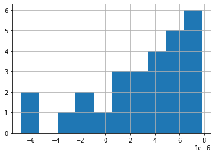

```python
delta['Percent diff'].hist()
```

```python
ils = delta.index[-1]
print('WORST IMPLND SEGMENT IS', ils)
```

```
WORST IMPLND SEGMENT IS 231
```

#### IMPLND IWATER SURO, Monthly

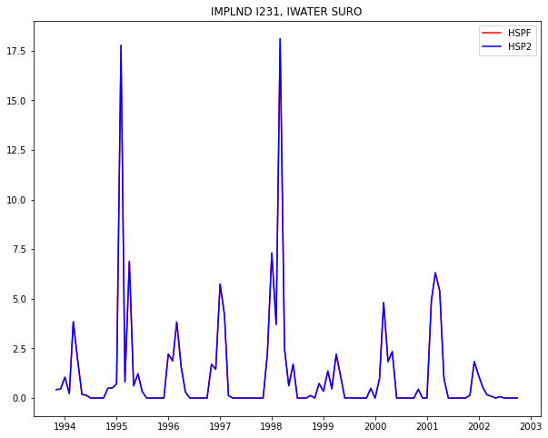

```python
plot('IMPLND', ils, 'IWATER', 'SURO', 'sum')
```

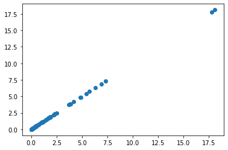

```python
scatter('IMPLND', ils, 'IWATER', 'SURO', 'sum')
```

#### IMPLND IWATER IMPEV, Monthly

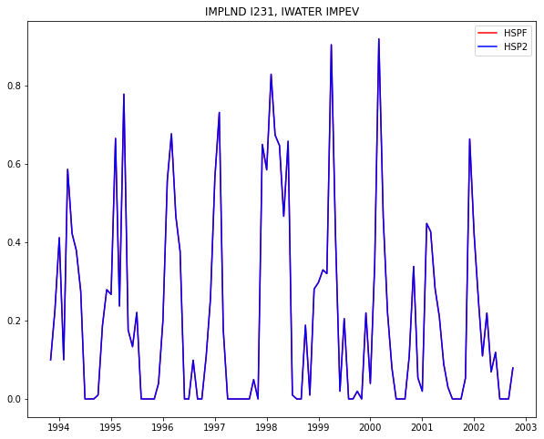

```python
plot('IMPLND', ils, 'IWATER', 'IMPEV', 'sum')
```

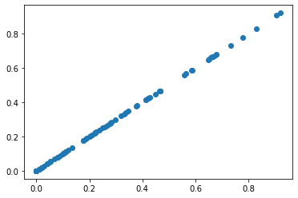

```python
scatter('IMPLND', ils, 'IWATER', 'IMPEV', 'sum')
```

#### IMPLND IWATER PET, Monthly

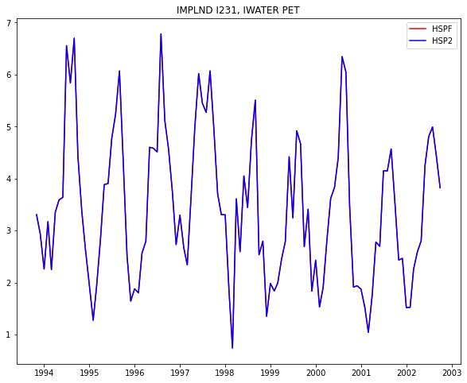

```python
plot('IMPLND', ils, 'IWATER', 'PET', 'sum')
```

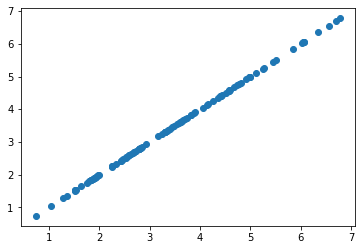

```python
scatter('IMPLND', ils, 'IWATER', 'PET', 'sum')
```

#### IMPLND IWATER RETS, Monthly

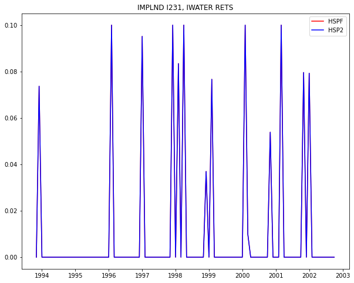

```python
plot('IMPLND', ils, 'IWATER', 'RETS', 'last')
```

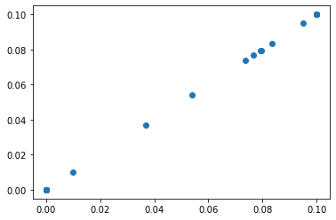

```python
scatter('IMPLND', ils, 'IWATER', 'RETS', 'last')
```

#### IMPLND IWATER SUPY, Monthly

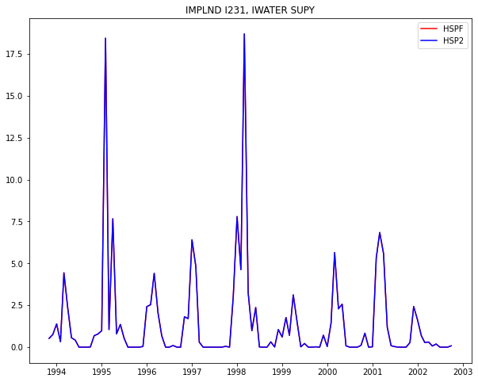

```python
plot('IMPLND', ils, 'IWATER', 'SUPY', 'sum')
```

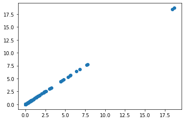

```python
scatter('IMPLND', ils, 'IWATER', 'SUPY', 'sum')
```

#### IMPLND IWATER SURS, Monthly

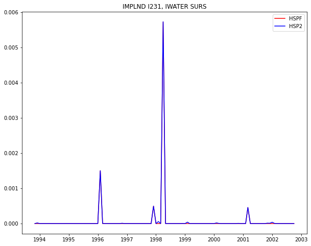

```python
plot('IMPLND', ils, 'IWATER', 'SURS', 'last')
```

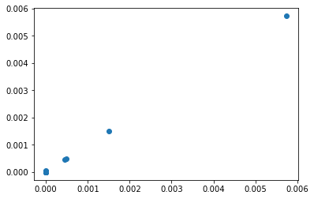

```python
scatter('IMPLND', ils, 'IWATER', 'SURS', 'last')
```

## Automate checking PERLNDs for PERO

```python
perlndkeys = summary[(summary.Frequency=='Monthly') & (summary.Operation=='PERLND')]
perlndkeys
```

|  | Operation | Activity | segment | Frequency | Shape | Start | Stop |
| --- | --- | --- | --- | --- | --- | --- | --- |
| PERLND_PWATER_011_4 | PERLND | PWATER | 11 | Monthly | (108, 27) | 1993-11-01 | 2002-10-01 |
| PERLND_PWATER_012_4 | PERLND | PWATER | 12 | Monthly | (108, 32) | 1993-11-01 | 2002-10-01 |
| PERLND_PWATER_013_4 | PERLND | PWATER | 13 | Monthly | (108, 32) | 1993-11-01 | 2002-10-01 |
| PERLND_PWATER_014_4 | PERLND | PWATER | 14 | Monthly | (108, 32) | 1993-11-01 | 2002-10-01 |
| PERLND_PWATER_015_4 | PERLND | PWATER | 15 | Monthly | (108, 32) | 1993-11-01 | 2002-10-01 |
| ... | ... | ... | ... | ... | ... | ... | ... |
| PERLND_PWATER_302_4 | PERLND | PWATER | 302 | Monthly | (108, 32) | 1993-11-01 | 2002-10-01 |
| PERLND_PWATER_303_4 | PERLND | PWATER | 303 | Monthly | (108, 32) | 1993-11-01 | 2002-10-01 |
| PERLND_PWATER_304_4 | PERLND | PWATER | 304 | Monthly | (108, 32) | 1993-11-01 | 2002-10-01 |
| PERLND_PWATER_305_4 | PERLND | PWATER | 305 | Monthly | (108, 32) | 1993-11-01 | 2002-10-01 |
| PERLND_PWATER_306_4 | PERLND | PWATER | 306 | Monthly | (108, 32) | 1993-11-01 | 2002-10-01 |

129 rows × 7 columns

```python
delta = monthlyoutflow(perlndkeys, 'PERO')
delta
```

|  | HSP2 SUM | HSPF SUM | Percent diff | abs(Percent diff) |
| --- | --- | --- | --- | --- |
| 055 | 64.7859 | 64.7859 | -0.0000 | 0.0000 |
| 226 | 29.4270 | 29.4270 | -0.0000 | 0.0000 |
| 222 | 45.9145 | 45.9145 | -0.0000 | 0.0000 |
| 124 | 56.8129 | 56.8129 | -0.0000 | 0.0000 |
| 235 | 85.6543 | 85.6543 | -0.0000 | 0.0000 |
| ... | ... | ... | ... | ... |
| 152 | 34.4905 | 34.4905 | -0.0002 | 0.0002 |
| 111 | 7.1259 | 7.1259 | 0.0002 | 0.0002 |
| 195 | 78.4794 | 78.4795 | 0.0002 | 0.0002 |
| 306 | 72.7249 | 72.7248 | -0.0002 | 0.0002 |
| 125 | 59.8037 | 59.8035 | -0.0003 | 0.0003 |

129 rows × 4 columns

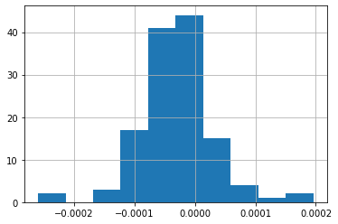

```python
delta['Percent diff'].hist()
```

```python
pls = delta.index[-1]
print('WORST PERLND SEGMENT IS', pls)
```

```
WORST PERLND SEGMENT IS 125
```

#### PERLND PWATER AGWO

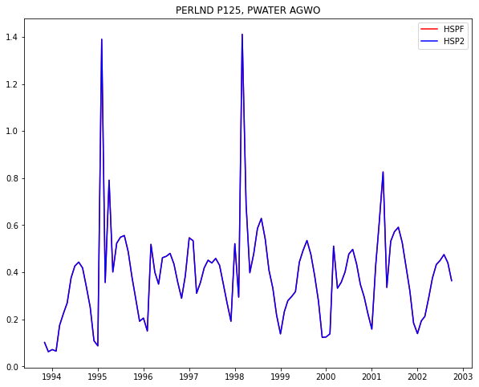

```python
plot('PERLND', pls, 'PWATER', 'AGWO', 'sum')
```

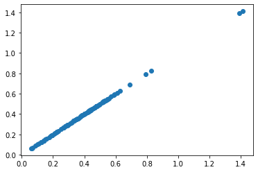

```python
scatter('PERLND', pls, 'PWATER', 'AGWO', 'sum')
```

#### PERLND PWATER BASET

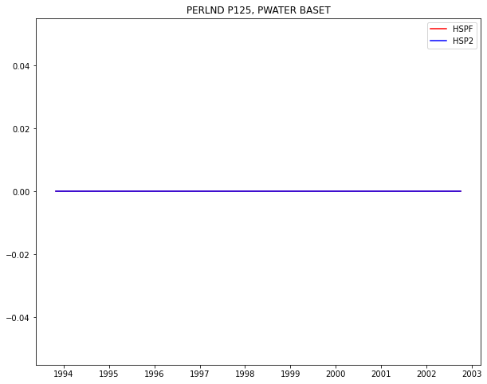

```python
plot('PERLND', pls, 'PWATER', 'BASET', 'sum')
```

[figure not shown]

```python
scatter('PERLND', pls, 'PWATER', 'BASET', 'sum')
```

##### PERLND PWATER CEPE

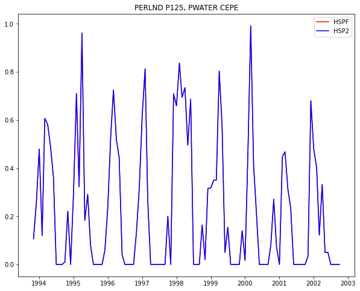

```python
plot('PERLND', pls, 'PWATER', 'CEPE', 'sum')
```

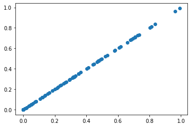

```python
scatter('PERLND', pls, 'PWATER', 'CEPE', 'sum')
```

#### PERLND PWATER IFWI

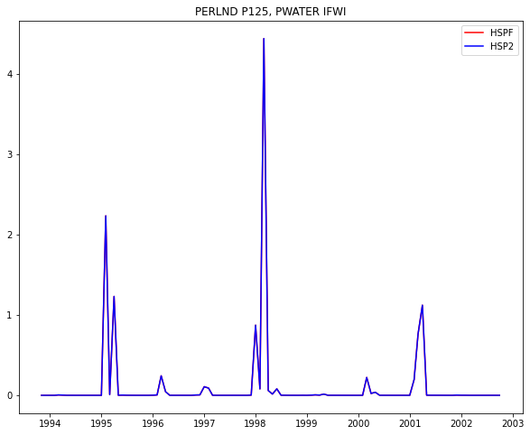

```python
plot('PERLND', pls, 'PWATER', 'IFWI', 'sum')
```

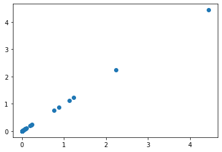

```python
scatter('PERLND', pls, 'PWATER', 'IFWI', 'sum')
```

#### PERLND PWATER IFWO

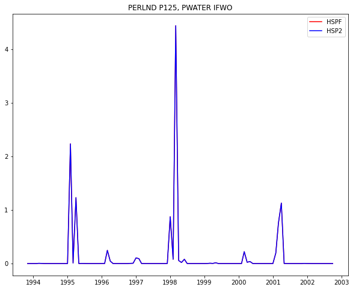

```python
plot('PERLND', pls, 'PWATER', 'IFWO', 'sum')
```

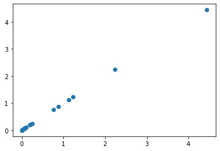

```python
scatter('PERLND', pls, 'PWATER', 'IFWO', 'sum')
```

#### PERLND PWATER IGWI

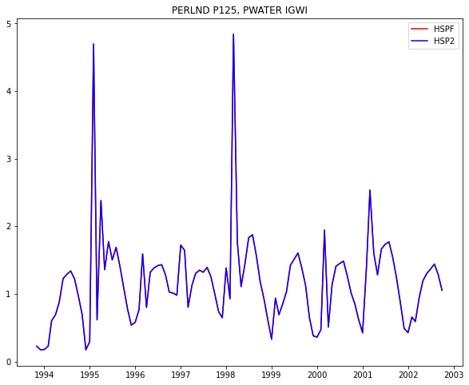

```python
plot('PERLND', pls, 'PWATER', 'IGWI', 'sum')
```

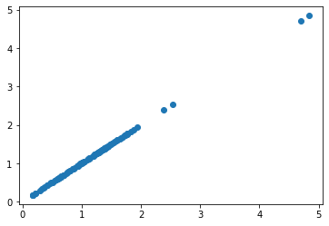

```python
scatter('PERLND', pls, 'PWATER', 'IGWI', 'sum')
```

#### PERLND PWATER INFIL

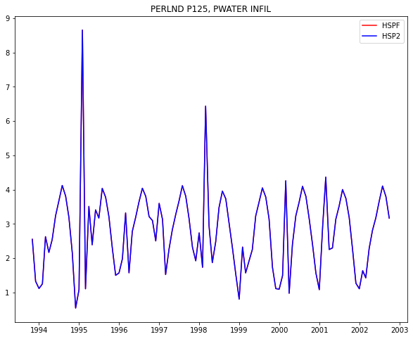

```python
plot('PERLND', pls, 'PWATER', 'INFIL', 'sum')
```

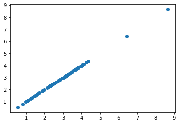

```python
scatter('PERLND', pls, 'PWATER', 'INFIL', 'sum')
```

#### PERLND PWATER LZET

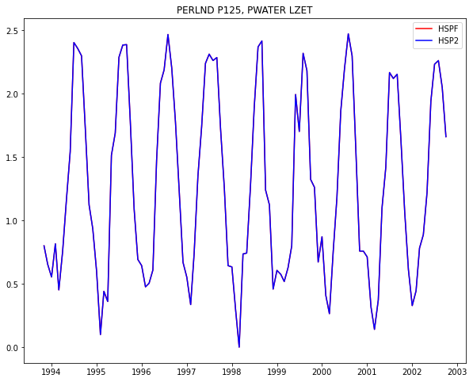

```python
plot('PERLND', pls, 'PWATER', 'LZET', 'sum')
```

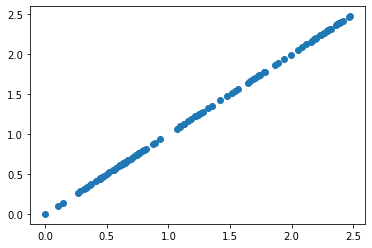

```python
scatter('PERLND', pls, 'PWATER', 'LZET', 'sum')
```